# 241213

241213 강의내용

- Noun: 명사
- Verb: 동사
- Adjective: 형용사
- Determiner: 관형사
- Adverb: 부사
- Conjunction: 접속사
- Exclamation: 감탄사
- Josa: 조사
- PreEomi: 선어말어미
- Eomi: 어말어미
- Suffix: 접미사
- Punctuation: 구두점
- Foreign: 외국어, 한자 및 기타기호
- Alpha: 알파벳
- Number: 숫자
- Unknown: 미등록어
- KoreanParticle: 한글 입자
- Modifier: 수식어
- VerbPrefix: 동사 접두사
- Adjective: 형용사

```python
from konlpy.tag import Okt

okt = Okt()
text = "나는 학교에 갔습니다."

## 형태소 단위로 나눔
# rst = okt.morphs(text)
rst = okt.morphs(text , stem = True) # stem=True --> 동사의 원형을 맞춰줌 : 갔습니다 --> 가다
print(rst)

## 품사 태깅 (기본값: 튜플(단어, 품사))
# rst = okt.pos(text)
# rst = okt.pos(text, stem = True)
rst = okt.pos(text, stem = True, join = True) # join : 단어와 품사를 '/'로 연결
print(rst)

## 명사 추출
rst = okt.nouns(text)
print('명사:',rst)

## 정규화 (텍스트 불필요 부분 정리)
rst = okt.normalize('그래욬ㅋㅋㅋ')
print(rst)

## 어구(프레이즈): 특정한 의미를 지닌 단어들 모임
rst = okt.phrases('엄청난 폭우가 서울에 내렸습니다. 도로가 물에 잠겼어요')
print(rst)
```

```
['나', '는', '학교', '에', '가다', '.']
['나/Noun', '는/Josa', '학교/Noun', '에/Josa', '가다/Verb', './Punctuation']
명사: ['나', '학교']
그래요ㅋㅋㅋ
['엄청난 폭우', '서울', '도로', '폭우']
```

```python
## 복합명사 리스트화 예제 샘플

#-------Okt 기본세팅---------
from konlpy.tag import Okt
okt = Okt()
#----------------------------
text = "인공지능과 자연어처리 기술이 발전하고 있습니다. 인공 지능과 기계 학습도 중요합니다. 인공지능이 인공지능합니다."

tokens = text.split()
# print(tokens)

combined_nouns = []
current_combined = ""

for token in tokens:
    nouns = okt.nouns(token)
    print(nouns)
    for noun in nouns:
        if current_combined:
            current_combined += noun
        else:
            current_combined = noun

        if not (current_combined and (nouns.index(noun) < len(nouns) -1)):
            combined_nouns.append(current_combined)
            current_combined = ""

if current_combined:
    combined_nouns.append(current_combined)

print("-"*50)
print(combined_nouns)
```

```
['인공', '지능']
['자연어', '처리']
['기술']
['발전']
[]
['인공']
['지능']
['기계']
['학습']
[]
['인공', '지능']
['인공', '지능']
--------------------------------------------------
['인공지능', '자연어처리', '기술', '발전', '인공', '지능', '기계', '학습', '인공지능', '인공지능']
```

## 워드클라우드 (wordcloud)

```
['오늘', '정말', '맑은', '날씨', '기분', '맑은', '하늘', '아래', '산책', '하니', '마음', '것', '맑은', '날씨', '햇살', '피부', '기분', '맑은', '공기', '산책길', '핀', '꽃', '구경', '집', '창문', '맑은', '바람', '방', '안', '맑은', '하늘', '배경', '사진', '친구', '친구', '맑은', '하늘', '사진', '서로', '기분', '저녁', '맑은', '국물', '된장찌개', '맑은', '된장찌개', '맛', '정말', '하루', '때', '맑…
{'것': 1, '공기': 1, '구경': 1, '국물': 1, '기분': 4, '꽃': 1, '날씨': 2, '된장찌개': 2, '때': 1, '마음': 1, '맑은': 10, '맛': 1, '바람': 1, '방': 1, '배경': 1, '사진': 2, '산책': 1, '산책길': 1, '서로': 1, '수': 1, '아래': 1, '안': 1, '오늘': 1, '유지': 1, '저녁': 1, '정말': 2, '집': 1, '창문': 1, '친구': 2, '피부': 1, '핀': 1, '하늘': 3, '하니': 1, '하루': 1…
```

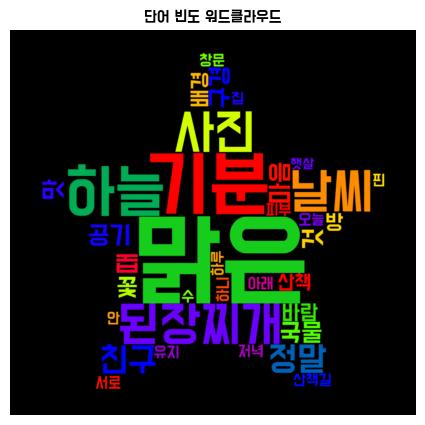

```python
import numpy as np
import matplotlib.pyplot as plt
from matplotlib import font_manager
from wordcloud import WordCloud
from konlpy.tag import Okt
from PIL import Image

def get_compound_nouns(text):

    okt = Okt()
    tokens = text.split()
    combined_nouns = []
    current_combined = ""

    for token in tokens:
        nouns = okt.nouns(token)

        for noun in nouns:
            if current_combined:
                current_combined += noun
            else:
                current_combined = noun

            if not (current_combined and (nouns.index(noun) < len(nouns) - 1)):
                combined_nouns.append(current_combined)
                current_combined = ""

    if current_combined:
        combined_nouns.append(current_combined)

    return combined_nouns

## 한글세팅 (워드클라우드, 맵플로립)
fontpath = r'C:\junhyuk\python\fonts\DoHyeon-Regular.ttf'
font_manager.fontManager.addfont(fontpath)
plt.rc('font', family='Do Hyeon')
plt.rcParams['axes.unicode_minus'] = False

# text = """인공지능은 현대 기술의 핵심입니다.
# 인공지능 기술은 우리의 일상을 변화시키고 있습니다.
# 기계학습과 딥러닝은 인공지능의 중요한 분야입니다.
# 데이터는 인공지능 발전의 핵심 동력입니다.
# 기술의 발전은 새로운 기회를 제공합니다. 딥러닝을 인공지능과 함께 공부 합시다."""
text = """오늘은 정말 맑은 날씨라서 기분이 맑았다.
맑은 하늘 아래 산책을 하니 마음도 맑아지는 것 같았다.
맑은 날씨에 어울리는 따뜻한 햇살이 피부에 닿아 기분이 좋았다.
맑은 공기를 마시며 산책길에 핀 꽃들을 구경했다.
집에 돌아와 창문을 열었더니 맑은 바람이 방 안으로 들어왔다.
맑은 하늘을 배경으로 찍은 사진을 친구에게 보내주었다.
친구도 맑은 하늘 사진을 보내주며 서로 기분이 좋다고 했다.
저녁에는 맑은 국물의 된장찌개를 만들어 먹었다.
맑은 된장찌개 맛이 정말 깔끔하고 깊었다.
하루가 끝날 때까지 맑은 기분을 유지할 수 있어 행복했다."""


words = get_compound_nouns(text)
print(words)

unique_words, counts = np.unique(words, return_counts=True)
freq = dict(zip(unique_words, counts))

print(freq)

mask_image = np.array(Image.open(r'C:\junhyuk\python\img\star.jpg'))

wordcloud = WordCloud(width = 800, height = 400,
                     background_color ='black',
                     font_path = fontpath,
                     mask = mask_image,
                     contour_color = 'black',
                     contour_width = 1,
                     colormap = 'prism').generate_from_frequencies(freq)

plt.figure(figsize=(10, 5))
plt.imshow(wordcloud, interpolation='bilinear')
plt.axis('off')
plt.title('단어 빈도 워드클라우드')
plt.show()
```

## 뉴스 워드클라우드

```python
# https://www.flaticon.com/icon-fonts-most-downloaded?weight=solid&type=uicon   아이콘 주소
```

```
['현행', '비단', '활용', '개', '개편안', '마련', '의견', '수렴', '냉도체', '육질', '판정제', '도입', '제안', '한돈협유통수출협', '입장차', '이미지투데이', '정부', '돼지고기', '등급제돼지등급제대한', '전면', '개편', '착수', '삼겹살', '과지방', '논란', '현행', '등급제', '단계', '활용', '지적', '손질', '나선', '것', '정부', '개편안', '대한', '생산자단체', '가공업계간', '의견', '향후', '정부', '방침', '이목', '축산물품질평가원…
{'가격': 1, '가공업계간': 1, '가공업체': 4, '가닥': 1, '가치': 1, '간소화': 4, '개': 4, '개선': 5, '개편': 1, '개편안': 8, '거리': 1, '거세': 1, '것': 9, '게': 1, '결과': 1, '결함육': 1, '경제': 1, '계획': 1, '과지방': 2, '관계자': 3, '관련': 5, '구간': 1, '구매': 1, '구상': 1, '국내': 1, '국정감사': 1, '국회': 1, '극복': 1, '극히': 1, '기관': 3, '기존': 1, '기준': 4, '나…
```

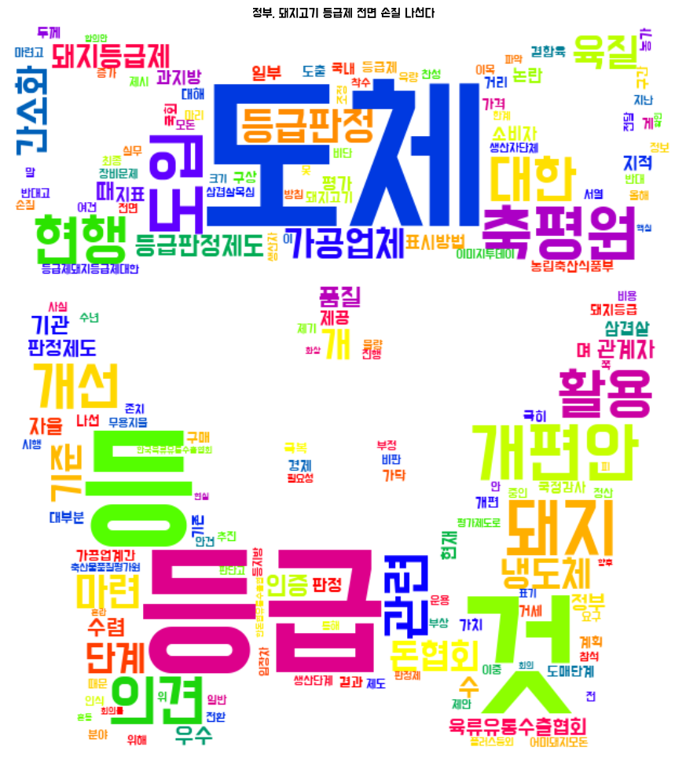

```python
# 네이버 기사
# 셀레니움

import numpy as np
import matplotlib.pyplot as plt
from matplotlib import font_manager
from wordcloud import WordCloud
from konlpy.tag import Okt
from PIL import Image
from selenium import webdriver
from selenium.webdriver.chrome.service import Service
from selenium.webdriver.chrome.options import Options
from selenium.webdriver.common.by import By
import time

chrome_options = Options()

# 브라우저 꺼짐 방지
chrome_options.add_experimental_option("detach", True)

# 불필요한 에러메시지 노출 방지
chrome_options.add_experimental_option("excludeSwitches", ["enable-logging"])

driver = webdriver.Chrome(options = chrome_options)

#----------------------------셀레니움 자동화 기본 값----------------------------------------

def get_compound_nouns(text):

    okt = Okt()
    tokens = text.split()
    combined_nouns = []
    current_combined = ""

    for token in tokens:
        nouns = okt.nouns(token)

        for noun in nouns:
            if current_combined:
                current_combined += noun
            else:
                current_combined = noun

            if not (current_combined and (nouns.index(noun) < len(nouns) - 1)):
                combined_nouns.append(current_combined)
                current_combined = ""

    if current_combined:
        combined_nouns.append(current_combined)

    return combined_nouns



url = 'https://n.news.naver.com/article/662/0000058204?cds=news_media_pc&type=editn'
driver.get(url)
text = driver.find_element(By.CSS_SELECTOR,"#dic_area").text
title = driver.find_element(By.CSS_SELECTOR,"#title_area").text
driver.quit()

## 한글세팅 (워드클라우드, 맵플로립)
fontpath = r'C:\junhyuk\python\fonts\DoHyeon-Regular.ttf'
font_manager.fontManager.addfont(fontpath)
plt.rc('font', family='Do Hyeon')
plt.rcParams['axes.unicode_minus'] = False


words = get_compound_nouns(text)
print(words)

unique_words, counts = np.unique(words, return_counts=True)
freq = dict(zip(unique_words, counts))

print(freq)

mask_image = np.array(Image.open(r'C:\junhyuk\python\img\pig.jpg'))

wordcloud = WordCloud(width = 800, height = 400,
                     background_color ='white',
                     font_path = fontpath,
                     mask = mask_image,
                     contour_color = 'white',
                     contour_width = 1,
                     colormap = 'prism').generate_from_frequencies(freq)

plt.figure(figsize=(20, 12))
plt.imshow(wordcloud, interpolation='bilinear')
plt.axis('off')
plt.title(title)
plt.savefig('워드클라우드1.png', bbox_inches='tight') # 워드클라우드 저장
plt.show()
```

```
{'가게': 2, '가까이': 1, '가득': 1, '가장': 1, '가족': 1, '개선': 1, '건강': 3, '검사': 1, '것': 4, '게티이미지뱅크매년': 1, '겨울': 1, '경우': 1, '고개': 1, '골다공증': 2, '골키퍼': 1, '과도': 3, '과정': 1, '관리': 2, '구부리': 3, '권장': 1, '규칙': 1, '그': 1, '그때': 1, '근막': 1, '근막통': 1, '근막통증': 1, '근육': 7, '근육통': 1, '기존': 1, '긴장': 2, '김장': 14, '김장철'…
```

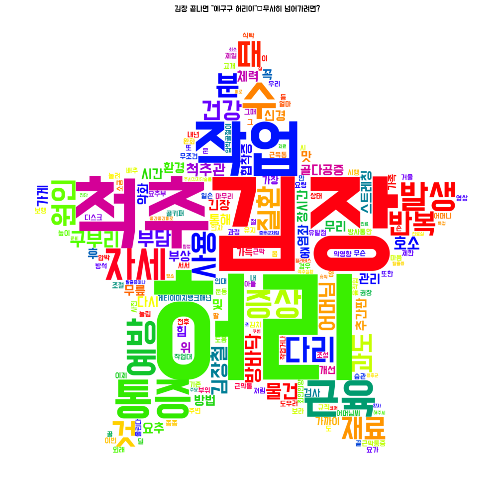

```python
# 네이버 기사
# beautifulsoup

import numpy as np
import matplotlib.pyplot as plt
from matplotlib import font_manager
from wordcloud import WordCloud
from konlpy.tag import Okt
from PIL import Image
from bs4 import BeautifulSoup
import requests

def get_compound_nouns(text):

    okt = Okt()
    tokens = text.split()
    combined_nouns = []
    current_combined = ""

    for token in tokens:
        nouns = okt.nouns(token)

        for noun in nouns:
            if current_combined:
                current_combined += noun
            else:
                current_combined = noun

            if not (current_combined and (nouns.index(noun) < len(nouns) - 1)):
                combined_nouns.append(current_combined)
                current_combined = ""

    if current_combined:
        combined_nouns.append(current_combined)

    return combined_nouns

def get_naver_news(url):
    headers ={
        'User-Agent' : 'Mozilla/5.0 (Windows NT 10.0; Win64; x64) AppleWebKit/537.36 (KHTML, like Gecko) Chrome/131.0.0.0 Safari/537.36'
    }
    response = requests.get(url, headers=headers)
    soup = BeautifulSoup(response.text, 'html.parser')

    # 제목 추출
    title = soup.select_one('#title_area').text.strip()

    # 본문 추출
    content = soup.select_one('#dic_area').text.strip()

    # return title + '\n' + content
    return title, content

## 한글세팅 (워드클라우드, 맵플로립)
fontpath = r'C:\junhyuk\python\fonts\DoHyeon-Regular.ttf'

## 맵플로립용 폰트 설정
font_manager.fontManager.addfont(fontpath)
plt.rc('font', family='Do Hyeon')
plt.rcParams['axes.unicode_minus'] = False

# 뉴스 스크랩(제목, 본문)
url = 'https://n.news.naver.com/article/296/0000084758?cds=news_media_pc&type=editn'
title, text = get_naver_news(url)

# 기사내용 워드클라우드
words = get_compound_nouns(text)
#print(words)


unique_words, counts = np.unique(words, return_counts=True)
freq = dict(zip(unique_words, counts))
print(freq)

mask_image = np.array(Image.open(r'C:\junhyuk\python\img\star.jpg'))

wordcloud = WordCloud(width = 800, height = 400,
                     background_color ='white',
                     font_path = fontpath,
                     mask = mask_image,
                     contour_color = 'white',
                     contour_width = 1,
                     colormap = 'prism').generate_from_frequencies(freq)

plt.figure(figsize=(20, 12))
plt.imshow(wordcloud, interpolation='bilinear')
plt.axis('off')
plt.title(title)
plt.savefig('워드클라우드2.png', bbox_inches='tight') # 워드클라우드 저장
plt.show()
```

## okt 품사별 단어 추출

```python
from konlpy.tag import Okt

okt = Okt()
text = "엄청난 폭우가 서울에 내렸습니다. 도로가 물에 잠겼어요ㅠㅠ"

tagged = okt.pos(text, stem = True)

print(tagged)
print("-"*100)

# 동사 추출
verbs = [word for word, pos in tagged if pos == 'Verb']
print("동사:",verbs)

# 형용사 추출
adjectives = [word for word, pos in tagged if pos == 'Adjective']
print("형용사:",adjectives)

# 부사 추출
adverbs = [word for word, pos in tagged if pos == 'Adverb']
print("부사:",adverbs)

# 조사 추출
josas = [word for word, pos in tagged if pos == 'Josa']
print("조사:",josas)
```

```
[('엄청나다', 'Adjective'), ('폭우', 'Noun'), ('가', 'Josa'), ('서울', 'Noun'), ('에', 'Josa'), ('내리다', 'Verb'), ('.', 'Punctuation'), ('도로', 'Noun'), ('가', 'Josa'), ('물', 'Noun'), ('에', 'Josa'), ('잠기다', 'Verb'), ('ㅠㅠ', 'KoreanParticle')]
----------------------------------------------------------------------------------------------------
동사: ['내리다', '잠기다']
형용사: ['엄청나다']
부사: []
조사: ['가', '에', '가', '에']
```

### okt.normalize

```python
from konlpy.tag import Okt
okt = Okt()

# 축약어 정규화
text1 = '그래욬ㅋㅋㅋ'
print(okt.normalize(text1))

# 반복 문자 정규화
text2 = '침짜aaaaa완전완전완전귀엽다!!!!!'
print(okt.normalize(text2))

# 이모티콘 정규화
text3 = "앜ㅋㅋㅋㅋㅋㅋㅋㅋㅋㅋㅋㅋ 웃겨요 ㅎㅎㅎㅎㅎㅎㅎㅎ"
print(okt.normalize(text3))

# 복합적인 예시
text4 = "안녕하세욬ㅋㅋㅋㅋㅋㅋ 완전 좋아요!!!!!!"
print(okt.normalize(text4))
```

```
그래요ㅋㅋㅋ
침짜aaaaa완전완전귀엽다!!!!!
아ㅋㅋㅋ 웃겨요 ㅎㅎㅎ
안녕하세요ㅋㅋㅋ 완전 좋아요!!!!!!
```

# 판다스

- 판다스는 데이터 작업에 사용되는 라이브러리로 데이터 분석, 정리, 탐색, 조작을 위한 기능이 포함되어 있다.
- 판다스를 사용하면 빅데이터 분석은 물론 통계 이론에 기반한 데이터 분석이 가능하다.
- 판다스는 정제되지 않은 데이트를 정리하여 가독성과 연관성이 높은 데이터로 만들 수 있다.
- 판다스는 결측치, 중복, 불균형 데이터와 같이 잘못된 값을 포함하는 행을 삭제 및 변경할 수도 있다.

```python
# !pip install pandas
# !pip list
```

```python
## 판다스 기본 형태
import pandas as pd

city = {
    '도시': ['서울', '부산', '울산'],
    '인구': [940, 330, 110]
}

## DataFrame : 2차원 데이터 처리
df = pd.DataFrame(city)
df
```

|  | 도시 | 인구 |
| --- | --- | --- |
| 0 | 서울 | 940 |
| 1 | 부산 | 330 |
| 2 | 울산 | 110 |

```python
import pandas as pd
city = ['서울', '부산', '울산']

## Series : 1차원 데이터 처리
df = pd.Series(city)
df
```

```
0    서울
1    부산
2    울산
dtype: object
```

```python
df = pd.Series(city, index = ['a', 'b', 'c'])
df
```

```
a    서울
b    부산
c    울산
dtype: object
```

```python
df['a']
```

```
'서울'
```

```python
df['b']
```

```
'부산'
```

```python
import pandas as pd
city = {'서울':940, '부산':330, '울산':110}
df = pd.Series(city)
df
```

```
서울    940
부산    330
울산    110
dtype: int64
```

```python
df['서울']
```

```
940
```

```python
import pandas as pd
data = [10, 20, 30, 40]
series = pd.Series(data)
print(series)
```

```
0    10
1    20
2    30
3    40
dtype: int64
```

```python
data = [10, 20, 30, 40]
index = ['a', 'b', 'c', 'd']
series = pd.Series(data, index=index)
print(series)
```

```
a    10
b    20
c    30
d    40
dtype: int64
```

```python
# 기본 통계량 계산
print("Mean:", series.mean())    # 평균
print("Sum:", series.sum())      # 합계
print("Max:", series.max())      # 최대값
print("Standard Deviation:", series.std())    # 표준편차
```

```
Mean: 25.0
Sum: 100
Max: 40
Standard Deviation: 12.909944487358056
```

```python
# 원소 접근
series['c']
```

```
30
```

```python
# 특정조건 요건 선택
filtered = series[series > 20]
print(filtered)
```

```
c    30
d    40
dtype: int64
```

```python
# 원소 수정
series['c'] = 100
```

```python
series
```

```
a     10
b     20
c    100
d     40
dtype: int64
```

```python
# 원소 추가
series['e'] = 50
print(series)
```

```
a     10
b     20
c    100
d     40
e     50
dtype: int64
```

```python
# 원소 삭제
series = series.drop('a')
print(series)
```

```
b     20
c    100
d     40
e     50
dtype: int64
```

```python
# 시리즈간 연산
data2 = [5, 15, 25, 35]
series2 = pd.Series(data2, index=['b', 'c', 'd', 'e'])
result = series + series2
print(result)
```

```
b     25
c    115
d     65
e     85
dtype: int64
```

```python
date_range = pd.date_range(start='2023-01-01', periods = 5)
date_range
```

```
DatetimeIndex(['2023-01-01', '2023-01-02', '2023-01-03', '2023-01-04',
               '2023-01-05'],
              dtype='datetime64[ns]', freq='D')
```

```python
time_series = pd.Series([1, 3, 5, 7, 9], index = date_range)
time_series
```

```
2023-01-01    1
2023-01-02    3
2023-01-03    5
2023-01-04    7
2023-01-05    9
Freq: D, dtype: int64
```

```python
# 시리즈(1차원)를 데이터프레임(2차원)으로 변환
df = time_series.to_frame(name='Values')
df
```

|  | Values |
| --- | --- |
| 2023-01-01 | 1 |
| 2023-01-02 | 3 |
| 2023-01-03 | 5 |
| 2023-01-04 | 7 |
| 2023-01-05 | 9 |

## 판다스 데이터프레임(DataFrame)

- 일반적으로 판다스에서는 데이터프레임이라고 하는 2차원 배열(행, 열 구성)을 사용한다.
- 데이터프레임은 2차원 배열 또는 행열로 구성된 2차원 테이블 구조를 가진다.
- 딕셔너리(Dictionary) 형태의 데이터로 데이터프레임을 만들 수 있다.
- 두 개의 시리즈가 모여서 데이터프레임을 생성하는 것과 같다.
- 딕셔너리의 키(key) 값은 컬럼명(필드명)으로 생성

```python
import pandas as pd

city = {
    '도시': ['서울', '부산', '울산'],
    '인구': [940, 330, 110]
}

df = pd.DataFrame(city)
df
```

|  | 도시 | 인구 |
| --- | --- | --- |
| 0 | 서울 | 940 |
| 1 | 부산 | 330 |
| 2 | 울산 | 110 |

```python
df['도시']
```

```
0    서울
1    부산
2    울산
Name: 도시, dtype: object
```

```python
df.loc[0]
```

```
도시     서울
인구    940
Name: 0, dtype: object
```

```python
df.loc[[0]]
```

|  | 도시 | 인구 |
| --- | --- | --- |
| 0 | 서울 | 940 |

```python
df.loc[[0,2]]
```

|  | 도시 | 인구 |
| --- | --- | --- |
| 0 | 서울 | 940 |
| 2 | 울산 | 110 |

```python
df.iloc[0:3]
```

|  | 도시 | 인구 |
| --- | --- | --- |
| 0 | 서울 | 940 |
| 1 | 부산 | 330 |
| 2 | 울산 | 110 |

```python
import pandas as pd
city = {
    '도시': ['서울', '부산', '울산'],
    '인구': [940, 330, 110]
}

df = pd.DataFrame(city, index = ['1등', '2등', '3등'])
df
```

|  | 도시 | 인구 |
| --- | --- | --- |
| 1등 | 서울 | 940 |
| 2등 | 부산 | 330 |
| 3등 | 울산 | 110 |

```python
df.loc['1등']
```

```
도시     서울
인구    940
Name: 1등, dtype: object
```

```python
df.loc[['1등']]
```

|  | 도시 | 인구 |
| --- | --- | --- |
| 1등 | 서울 | 940 |

```python
df.iloc[0:3]
```

|  | 도시 | 인구 |
| --- | --- | --- |
| 1등 | 서울 | 940 |
| 2등 | 부산 | 330 |
| 3등 | 울산 | 110 |

```python
import pandas as pd
data = [['김민재', 27, 75, 5428000],
        ['이강인', 22, 57, 3428000],
        ['박찬호', 50, 91, 8428000],
        ['차범근', 70, 80, 4428000],
        ['추신수', 43, 100, 4528000],
        ['손흥민', 31, 72, 7028000],
        ['황희찬', 28, 69, 2528000]]

df = pd.DataFrame(data, columns = ['성명', '나이', '몸무게', '급여'])
df
```

|  | 성명 | 나이 | 몸무게 | 급여 |
| --- | --- | --- | --- | --- |
| 0 | 김민재 | 27 | 75 | 5428000 |
| 1 | 이강인 | 22 | 57 | 3428000 |
| 2 | 박찬호 | 50 | 91 | 8428000 |
| 3 | 차범근 | 70 | 80 | 4428000 |
| 4 | 추신수 | 43 | 100 | 4528000 |
| 5 | 손흥민 | 31 | 72 | 7028000 |
| 6 | 황희찬 | 28 | 69 | 2528000 |

```python
df['성명']
```

```
0    김민재
1    이강인
2    박찬호
3    차범근
4    추신수
5    손흥민
6    황희찬
Name: 성명, dtype: object
```

```python
df[['성명', '급여']]
```

|  | 성명 | 급여 |
| --- | --- | --- |
| 0 | 김민재 | 5428000 |
| 1 | 이강인 | 3428000 |
| 2 | 박찬호 | 8428000 |
| 3 | 차범근 | 4428000 |
| 4 | 추신수 | 4528000 |
| 5 | 손흥민 | 7028000 |
| 6 | 황희찬 | 2528000 |

```python
#df['성명', '급여']  # 두 개 이상 컬럼은 반드시 [[ ]] 형식으로
```

```python
df.성명
```

```
0    김민재
1    이강인
2    박찬호
3    차범근
4    추신수
5    손흥민
6    황희찬
Name: 성명, dtype: object
```

### loc: location의 약자로 하나 이상의 지정된 행과 열

- .loc[행]
- .loc[행, 열]

```python
df.loc[[1,3]]
```

|  | 성명 | 나이 | 몸무게 | 급여 |
| --- | --- | --- | --- | --- |
| 1 | 이강인 | 22 | 57 | 3428000 |
| 3 | 차범근 | 70 | 80 | 4428000 |

```python
df.loc[0:2]
```

|  | 성명 | 나이 | 몸무게 | 급여 |
| --- | --- | --- | --- | --- |
| 0 | 김민재 | 27 | 75 | 5428000 |
| 1 | 이강인 | 22 | 57 | 3428000 |
| 2 | 박찬호 | 50 | 91 | 8428000 |

```python
df.loc[[2], ['성명']]
```

|  | 성명 |
| --- | --- |
| 2 | 박찬호 |

```python
df.loc[[0,2], ['성명','나이']]
```

|  | 성명 | 나이 |
| --- | --- | --- |
| 0 | 김민재 | 27 |
| 2 | 박찬호 | 50 |

```python
df.loc[0:3,['성명','나이']]
```

|  | 성명 | 나이 |
| --- | --- | --- |
| 0 | 김민재 | 27 |
| 1 | 이강인 | 22 |
| 2 | 박찬호 | 50 |
| 3 | 차범근 | 70 |

```python
df.loc[:3, ['성명']]
```

|  | 성명 |
| --- | --- |
| 0 | 김민재 |
| 1 | 이강인 |
| 2 | 박찬호 |
| 3 | 차범근 |

```python
df.loc[[0, 2, 4]]
```

|  | 성명 | 나이 | 몸무게 | 급여 |
| --- | --- | --- | --- | --- |
| 0 | 김민재 | 27 | 75 | 5428000 |
| 2 | 박찬호 | 50 | 91 | 8428000 |
| 4 | 추신수 | 43 | 100 | 4528000 |

```python
df.loc[0:3]
```

|  | 성명 | 나이 | 몸무게 | 급여 |
| --- | --- | --- | --- | --- |
| 0 | 김민재 | 27 | 75 | 5428000 |
| 1 | 이강인 | 22 | 57 | 3428000 |
| 2 | 박찬호 | 50 | 91 | 8428000 |
| 3 | 차범근 | 70 | 80 | 4428000 |

```python
df.iloc[0:3]
```

|  | 성명 | 나이 | 몸무게 | 급여 |
| --- | --- | --- | --- | --- |
| 0 | 김민재 | 27 | 75 | 5428000 |
| 1 | 이강인 | 22 | 57 | 3428000 |
| 2 | 박찬호 | 50 | 91 | 8428000 |

```python
df.loc[0, '급여']
```

```
5428000
```

```python
df.iloc[0,3]
```

```
5428000
```

```python
df.loc[:3,['성명']]
```

|  | 성명 |
| --- | --- |
| 0 | 김민재 |
| 1 | 이강인 |
| 2 | 박찬호 |
| 3 | 차범근 |

```python
df.iloc[:3,[0]]
```

|  | 성명 |
| --- | --- |
| 0 | 김민재 |
| 1 | 이강인 |
| 2 | 박찬호 |

```python
# 인덱스 0, 1, 3번 행과 0, 3 번째 컬럼('성명', '급여')을 찾는 방법을 비교한다.
df.loc[[0, 1, 3], ['성명','급여']]
```

|  | 성명 | 급여 |
| --- | --- | --- |
| 0 | 김민재 | 5428000 |
| 1 | 이강인 | 3428000 |
| 3 | 차범근 | 4428000 |

```python
df.iloc[[0,1,3],[0,3]]
```

|  | 성명 | 급여 |
| --- | --- | --- |
| 0 | 김민재 | 5428000 |
| 1 | 이강인 | 3428000 |
| 3 | 차범근 | 4428000 |

```python
df.loc[[0,1,3], '성명':'급여']
```

|  | 성명 | 나이 | 몸무게 | 급여 |
| --- | --- | --- | --- | --- |
| 0 | 김민재 | 27 | 75 | 5428000 |
| 1 | 이강인 | 22 | 57 | 3428000 |
| 3 | 차범근 | 70 | 80 | 4428000 |

```python
df.loc[0:3, '성명':'급여']
```

|  | 성명 | 나이 | 몸무게 | 급여 |
| --- | --- | --- | --- | --- |
| 0 | 김민재 | 27 | 75 | 5428000 |
| 1 | 이강인 | 22 | 57 | 3428000 |
| 2 | 박찬호 | 50 | 91 | 8428000 |
| 3 | 차범근 | 70 | 80 | 4428000 |

```python
df.iloc[[0,1,3], 0:4]
```

|  | 성명 | 나이 | 몸무게 | 급여 |
| --- | --- | --- | --- | --- |
| 0 | 김민재 | 27 | 75 | 5428000 |
| 1 | 이강인 | 22 | 57 | 3428000 |
| 3 | 차범근 | 70 | 80 | 4428000 |

- loc: 행 인덱스명, 컬럼명 접근 (명으로 접근)
- iloc: 행 인덱스번호, 컬럼 인덱스 접근 (번호로 접근)
- 개별 접근: 대괄호 사용
- 범위(슬라이싱) 접근: 대괄호 사용안함

```python
df.iloc[:3,:2]
```

|  | 성명 | 나이 |
| --- | --- | --- |
| 0 | 김민재 | 27 |
| 1 | 이강인 | 22 |
| 2 | 박찬호 | 50 |

```python
df.iloc[:,:3]
```

|  | 성명 | 나이 | 몸무게 |
| --- | --- | --- | --- |
| 0 | 김민재 | 27 | 75 |
| 1 | 이강인 | 22 | 57 |
| 2 | 박찬호 | 50 | 91 |
| 3 | 차범근 | 70 | 80 |
| 4 | 추신수 | 43 | 100 |
| 5 | 손흥민 | 31 | 72 |
| 6 | 황희찬 | 28 | 69 |

```python
df.iloc[::2,:]
```

|  | 성명 | 나이 | 몸무게 | 급여 |
| --- | --- | --- | --- | --- |
| 0 | 김민재 | 27 | 75 | 5428000 |
| 2 | 박찬호 | 50 | 91 | 8428000 |
| 4 | 추신수 | 43 | 100 | 4528000 |
| 6 | 황희찬 | 28 | 69 | 2528000 |

```python
df
```

|  | 성명 | 나이 | 몸무게 | 급여 |
| --- | --- | --- | --- | --- |
| 0 | 김민재 | 27 | 75 | 5428000 |
| 1 | 이강인 | 22 | 57 | 3428000 |
| 2 | 박찬호 | 50 | 91 | 8428000 |
| 3 | 차범근 | 70 | 80 | 4428000 |
| 4 | 추신수 | 43 | 100 | 4528000 |
| 5 | 손흥민 | 31 | 72 | 7028000 |
| 6 | 황희찬 | 28 | 69 | 2528000 |

```python
# '급여' 컬럼의 데이터에서 5백만원 이상인 행
df.loc[df['급여']>=5000000]
```

|  | 성명 | 나이 | 몸무게 | 급여 |
| --- | --- | --- | --- | --- |
| 0 | 김민재 | 27 | 75 | 5428000 |
| 2 | 박찬호 | 50 | 91 | 8428000 |
| 5 | 손흥민 | 31 | 72 | 7028000 |

```python
# '나이' 컬럼의 데이터에서 30 이상
df.loc[(df['나이']>=30)]
```

|  | 성명 | 나이 | 몸무게 | 급여 |
| --- | --- | --- | --- | --- |
| 2 | 박찬호 | 50 | 91 | 8428000 |
| 3 | 차범근 | 70 | 80 | 4428000 |
| 4 | 추신수 | 43 | 100 | 4528000 |
| 5 | 손흥민 | 31 | 72 | 7028000 |

```python
# '나이' 컬럼의 데이터에서 30 이상이고 35 이하
# 조건이 두 개 이상일 경우 각각 조건을 () 묶는다.
df.loc[(df['나이']>=30) & (df['나이']<=35)]
```

|  | 성명 | 나이 | 몸무게 | 급여 |
| --- | --- | --- | --- | --- |
| 5 | 손흥민 | 31 | 72 | 7028000 |

```python
# '급여' 컬럼의 데이터에서 5백만원 이상인 행에 대해 '성명' 컬럼만
df.loc[df['급여']>=5000000, ['성명']]
```

|  | 성명 |
| --- | --- |
| 0 | 김민재 |
| 2 | 박찬호 |
| 5 | 손흥민 |

```python
# '급여' 컬럼의 데이터에서 5백만원 이상인 행에 대해 '성명' 부터 '몸무게' 컬럼만
df.loc[df['급여']>=5000000, '성명':'몸무게']
```

|  | 성명 | 나이 | 몸무게 |
| --- | --- | --- | --- |
| 0 | 김민재 | 27 | 75 |
| 2 | 박찬호 | 50 | 91 |
| 5 | 손흥민 | 31 | 72 |

```python
df
```

|  | 성명 | 나이 | 몸무게 | 급여 |
| --- | --- | --- | --- | --- |
| 0 | 김민재 | 27 | 75 | 5428000 |
| 1 | 이강인 | 22 | 57 | 3428000 |
| 2 | 박찬호 | 50 | 91 | 8428000 |
| 3 | 차범근 | 70 | 80 | 4428000 |
| 4 | 추신수 | 43 | 100 | 4528000 |
| 5 | 손흥민 | 31 | 72 | 7028000 |
| 6 | 황희찬 | 28 | 69 | 2528000 |

```python
df['체질량'] =' '
df
```

|  | 성명 | 나이 | 몸무게 | 급여 | 체질량 |
| --- | --- | --- | --- | --- | --- |
| 0 | 김민재 | 27 | 75 | 5428000 |  |
| 1 | 이강인 | 22 | 57 | 3428000 |  |
| 2 | 박찬호 | 50 | 91 | 8428000 |  |
| 3 | 차범근 | 70 | 80 | 4428000 |  |
| 4 | 추신수 | 43 | 100 | 4528000 |  |
| 5 | 손흥민 | 31 | 72 | 7028000 |  |
| 6 | 황희찬 | 28 | 69 | 2528000 |  |

```python
df.loc[df['몸무게']>80,['체질량']] = '비만'
df
```

[output not shown]

### df.drop: 특정 행과 컬럼을 삭제

- axis = 0: 세로축(행)
- axis = 1: 가로축(열<컬럼>)

```python
df
```

|  | 성명 | 나이 | 몸무게 | 급여 | 체질량 |
| --- | --- | --- | --- | --- | --- |
| 0 | 김민재 | 27 | 75 | 5428000 |  |
| 1 | 이강인 | 22 | 57 | 3428000 |  |
| 2 | 박찬호 | 50 | 91 | 8428000 | 비만 |
| 3 | 차범근 | 70 | 80 | 4428000 |  |
| 4 | 추신수 | 43 | 100 | 4528000 | 비만 |
| 5 | 손흥민 | 31 | 72 | 7028000 |  |
| 6 | 황희찬 | 28 | 69 | 2528000 |  |

```python
df.drop(['몸무게','체질량'], axis = 1)
```

|  | 성명 | 나이 | 급여 |
| --- | --- | --- | --- |
| 0 | 김민재 | 27 | 5428000 |
| 1 | 이강인 | 22 | 3428000 |
| 2 | 박찬호 | 50 | 8428000 |
| 3 | 차범근 | 70 | 4428000 |
| 4 | 추신수 | 43 | 4528000 |
| 5 | 손흥민 | 31 | 7028000 |
| 6 | 황희찬 | 28 | 2528000 |

```python
df
```

|  | 성명 | 나이 | 몸무게 | 급여 | 체질량 |
| --- | --- | --- | --- | --- | --- |
| 0 | 김민재 | 27 | 75 | 5428000 |  |
| 1 | 이강인 | 22 | 57 | 3428000 |  |
| 2 | 박찬호 | 50 | 91 | 8428000 | 비만 |
| 3 | 차범근 | 70 | 80 | 4428000 |  |
| 4 | 추신수 | 43 | 100 | 4528000 | 비만 |
| 5 | 손흥민 | 31 | 72 | 7028000 |  |
| 6 | 황희찬 | 28 | 69 | 2528000 |  |

```python
df2 = df.drop(['몸무게','체질량'], axis = 1)
df2
```

|  | 성명 | 나이 | 급여 |
| --- | --- | --- | --- |
| 0 | 김민재 | 27 | 5428000 |
| 1 | 이강인 | 22 | 3428000 |
| 2 | 박찬호 | 50 | 8428000 |
| 3 | 차범근 | 70 | 4428000 |
| 4 | 추신수 | 43 | 4528000 |
| 5 | 손흥민 | 31 | 7028000 |
| 6 | 황희찬 | 28 | 2528000 |

```python
df
```

|  | 성명 | 나이 | 몸무게 | 급여 | 체질량 |
| --- | --- | --- | --- | --- | --- |
| 0 | 김민재 | 27 | 75 | 5428000 |  |
| 1 | 이강인 | 22 | 57 | 3428000 |  |
| 2 | 박찬호 | 50 | 91 | 8428000 | 비만 |
| 3 | 차범근 | 70 | 80 | 4428000 |  |
| 4 | 추신수 | 43 | 100 | 4528000 | 비만 |
| 5 | 손흥민 | 31 | 72 | 7028000 |  |
| 6 | 황희찬 | 28 | 69 | 2528000 |  |

```python
# 원본 데이터 삭제시 inplce = True
df.drop(['몸무게','체질량'], axis = 1, inplace = True)
df
```

|  | 성명 | 나이 | 급여 |
| --- | --- | --- | --- |
| 0 | 김민재 | 27 | 5428000 |
| 1 | 이강인 | 22 | 3428000 |
| 2 | 박찬호 | 50 | 8428000 |
| 3 | 차범근 | 70 | 4428000 |
| 4 | 추신수 | 43 | 4528000 |
| 5 | 손흥민 | 31 | 7028000 |
| 6 | 황희찬 | 28 | 2528000 |

```python
df.drop('체질량', axis = 1, inplace = True)
```

```python
df
```

|  | 성명 | 나이 | 몸무게 | 급여 |
| --- | --- | --- | --- | --- |
| 0 | 김민재 | 27 | 75 | 5428000 |
| 1 | 이강인 | 22 | 57 | 3428000 |
| 2 | 박찬호 | 50 | 91 | 8428000 |
| 3 | 차범근 | 70 | 80 | 4428000 |
| 4 | 추신수 | 43 | 100 | 4528000 |
| 5 | 손흥민 | 31 | 72 | 7028000 |
| 6 | 황희찬 | 28 | 69 | 2528000 |

```python
df.drop(columns = '몸무게')
```

|  | 성명 | 나이 | 급여 |
| --- | --- | --- | --- |
| 0 | 김민재 | 27 | 5428000 |
| 1 | 이강인 | 22 | 3428000 |
| 2 | 박찬호 | 50 | 8428000 |
| 3 | 차범근 | 70 | 4428000 |
| 4 | 추신수 | 43 | 4528000 |
| 5 | 손흥민 | 31 | 7028000 |
| 6 | 황희찬 | 28 | 2528000 |

```python
df
```

|  | 성명 | 나이 | 몸무게 | 급여 |
| --- | --- | --- | --- | --- |
| 0 | 김민재 | 27 | 75 | 5428000 |
| 1 | 이강인 | 22 | 57 | 3428000 |
| 2 | 박찬호 | 50 | 91 | 8428000 |
| 3 | 차범근 | 70 | 80 | 4428000 |
| 4 | 추신수 | 43 | 100 | 4528000 |
| 5 | 손흥민 | 31 | 72 | 7028000 |
| 6 | 황희찬 | 28 | 69 | 2528000 |

```python
df.drop(0)    ### 기본값: axis = 0, 행, 0: 인덱스명
# df.drop(0, axis = 0)
```

|  | 성명 | 나이 | 몸무게 | 급여 |
| --- | --- | --- | --- | --- |
| 1 | 이강인 | 22 | 57 | 3428000 |
| 2 | 박찬호 | 50 | 91 | 8428000 |
| 3 | 차범근 | 70 | 80 | 4428000 |
| 4 | 추신수 | 43 | 100 | 4528000 |
| 5 | 손흥민 | 31 | 72 | 7028000 |
| 6 | 황희찬 | 28 | 69 | 2528000 |

```python
df.drop(df.index[0:2]) # 행의 범위를 지정해서 삭제 (df.index를 활용)
```

|  | 성명 | 나이 | 몸무게 | 급여 |
| --- | --- | --- | --- | --- |
| 2 | 박찬호 | 50 | 91 | 8428000 |
| 3 | 차범근 | 70 | 80 | 4428000 |
| 4 | 추신수 | 43 | 100 | 4528000 |
| 5 | 손흥민 | 31 | 72 | 7028000 |
| 6 | 황희찬 | 28 | 69 | 2528000 |

```python
df.drop(df.index[2:4])  # 행의 범위를 지정해서 삭제 (df.index를 활용)
```

|  | 성명 | 나이 | 몸무게 | 급여 |
| --- | --- | --- | --- | --- |
| 0 | 김민재 | 27 | 75 | 5428000 |
| 1 | 이강인 | 22 | 57 | 3428000 |
| 4 | 추신수 | 43 | 100 | 4528000 |
| 5 | 손흥민 | 31 | 72 | 7028000 |
| 6 | 황희찬 | 28 | 69 | 2528000 |

```python
df.drop(df.iloc[2:4].index) # 행의 범위를 지정해서 삭제 (df.iloc[].index를 활용)
```

|  | 성명 | 나이 | 몸무게 | 급여 |
| --- | --- | --- | --- | --- |
| 0 | 김민재 | 27 | 75 | 5428000 |
| 1 | 이강인 | 22 | 57 | 3428000 |
| 4 | 추신수 | 43 | 100 | 4528000 |
| 5 | 손흥민 | 31 | 72 | 7028000 |
| 6 | 황희찬 | 28 | 69 | 2528000 |

```python
df.iloc[:, [0,1,3]]
```

|  | 성명 | 나이 | 급여 |
| --- | --- | --- | --- |
| 0 | 김민재 | 27 | 5428000 |
| 1 | 이강인 | 22 | 3428000 |
| 2 | 박찬호 | 50 | 8428000 |
| 3 | 차범근 | 70 | 4428000 |
| 4 | 추신수 | 43 | 4528000 |
| 5 | 손흥민 | 31 | 7028000 |
| 6 | 황희찬 | 28 | 2528000 |

```python
df.iloc[:, [0,1,3]].drop('나이', axis = 1)
```

|  | 성명 | 급여 |
| --- | --- | --- |
| 0 | 김민재 | 5428000 |
| 1 | 이강인 | 3428000 |
| 2 | 박찬호 | 8428000 |
| 3 | 차범근 | 4428000 |
| 4 | 추신수 | 4528000 |
| 5 | 손흥민 | 7028000 |
| 6 | 황희찬 | 2528000 |

## .str() 메서드

- [문자열 추출]
  - .str.len(): 각 문자열의 길이를 반환한다.
  - .str.split(): 문자열을 특정 구분자를 기준으로 분할한다.
  - .str.get(): 문자열의 특정 위치에 있는 문자를 반환한다.
- [문자열 변환]
  - .str.lower(): 모든 문자열을 소문자로 변환한다.
  - .str.upper(): 모든 문자열을 대문자로 변환한다.
  - .str.capitalize(): 각 문자열의 첫 문자를 대문자로 변환한다.
- [문자열 처리]
  - .str.contains(): 특정 문자열이 포함되어 있는지 확인한다.
  - .str.replace(): 특정 문자열을 다른 문자열로 대체다.
  - .str.findall(): 정규 표현식과 일치하는 모든 문자열을 리스트로 반환한다.
  - .str.strip(): 문자열 양 끝에 포함된 공백을 제거

```python
import pandas as pd

data = ['김예찬, m, 부장, 010-1234-5678, 서울시 강남구 삼성동',
        '이하은, f, 인턴, 010-8765-4321, 부산시 해운대구 우동',
        '박지현, f, 과장, 010-1357-2468, 대구시 수성구 범어동',
        '최준호, m, 임시, 010-1928-3746, 인천시 연수구 송도동',
       '김예서, f, 과장, 010-2846-5937, 천안시 서북구 두정동']
```

```python
df = pd.DataFrame(data, columns = ['직원데이터'])
df
```

|  | 직원데이터 |
| --- | --- |
| 0 | 김예찬, m, 부장, 010-1234-5678, 서울시 강남구 삼성동 |
| 1 | 이하은, f, 인턴, 010-8765-4321, 부산시 해운대구 우동 |
| 2 | 박지현, f, 과장, 010-1357-2468, 대구시 수성구 범어동 |
| 3 | 최준호, m, 임시, 010-1928-3746, 인천시 연수구 송도동 |
| 4 | 김예서, f, 과장, 010-2846-5937, 천안시 서북구 두정동 |

```python
# expand=True 는 각 행의 문자열을 분할한 다음, 분할된 각가의 데이터를 별도의 컬럼으로 저장한다.
df = df['직원데이터'].str.split(',', expand = True)
df
```

|  | 0 | 1 | 2 | 3 | 4 |
| --- | --- | --- | --- | --- | --- |
| 0 | 김예찬 | m | 부장 | 010-1234-5678 | 서울시 강남구 삼성동 |
| 1 | 이하은 | f | 인턴 | 010-8765-4321 | 부산시 해운대구 우동 |
| 2 | 박지현 | f | 과장 | 010-1357-2468 | 대구시 수성구 범어동 |
| 3 | 최준호 | m | 임시 | 010-1928-3746 | 인천시 연수구 송도동 |
| 4 | 김예서 | f | 과장 | 010-2846-5937 | 천안시 서북구 두정동 |

```python
df.columns = ['성명', '성별', '직급', '전화번호', '주소']
df
```

|  | 성명 | 성별 | 직급 | 전화번호 | 주소 |
| --- | --- | --- | --- | --- | --- |
| 0 | 김예찬 | m | 부장 | 010-1234-5678 | 서울시 강남구 삼성동 |
| 1 | 이하은 | f | 인턴 | 010-8765-4321 | 부산시 해운대구 우동 |
| 2 | 박지현 | f | 과장 | 010-1357-2468 | 대구시 수성구 범어동 |
| 3 | 최준호 | m | 임시 | 010-1928-3746 | 인천시 연수구 송도동 |
| 4 | 김예서 | f | 과장 | 010-2846-5937 | 천안시 서북구 두정동 |

```python
df['성별'] = df['성별'].str.upper()
```

```python
df
```

|  | 성명 | 성별 | 직급 | 전화번호 | 주소 |
| --- | --- | --- | --- | --- | --- |
| 0 | 김예찬 | M | 부장 | 010-1234-5678 | 서울시 강남구 삼성동 |
| 1 | 이하은 | F | 인턴 | 010-8765-4321 | 부산시 해운대구 우동 |
| 2 | 박지현 | F | 과장 | 010-1357-2468 | 대구시 수성구 범어동 |
| 3 | 최준호 | M | 임시 | 010-1928-3746 | 인천시 연수구 송도동 |
| 4 | 김예서 | F | 과장 | 010-2846-5937 | 천안시 서북구 두정동 |

```python
df['성별'] = df['성별'].str.replace('M',"Male")
df
```

|  | 성명 | 성별 | 직급 | 전화번호 | 주소 |
| --- | --- | --- | --- | --- | --- |
| 0 | 김예찬 | Male | 부장 | 010-1234-5678 | 서울시 강남구 삼성동 |
| 1 | 이하은 | F | 인턴 | 010-8765-4321 | 부산시 해운대구 우동 |
| 2 | 박지현 | F | 과장 | 010-1357-2468 | 대구시 수성구 범어동 |
| 3 | 최준호 | Male | 임시 | 010-1928-3746 | 인천시 연수구 송도동 |
| 4 | 김예서 | F | 과장 | 010-2846-5937 | 천안시 서북구 두정동 |

```python
df['성별'] = df['성별'].str.replace('F',"Female")
df
```

|  | 성명 | 성별 | 직급 | 전화번호 | 주소 |
| --- | --- | --- | --- | --- | --- |
| 0 | 김예찬 | Male | 부장 | 010-1234-5678 | 서울시 강남구 삼성동 |
| 1 | 이하은 | Female | 인턴 | 010-8765-4321 | 부산시 해운대구 우동 |
| 2 | 박지현 | Female | 과장 | 010-1357-2468 | 대구시 수성구 범어동 |
| 3 | 최준호 | Male | 임시 | 010-1928-3746 | 인천시 연수구 송도동 |
| 4 | 김예서 | Female | 과장 | 010-2846-5937 | 천안시 서북구 두정동 |

```python
df['성별'] = df['성별'].str.replace("Male",'남성').str.replace("Female",'여성')
df
```

|  | 성명 | 성별 | 직급 | 전화번호 | 주소 |
| --- | --- | --- | --- | --- | --- |
| 0 | 김예찬 | 남성 | 부장 | 010-1234-5678 | 서울시 강남구 삼성동 |
| 1 | 이하은 | 여성 | 인턴 | 010-8765-4321 | 부산시 해운대구 우동 |
| 2 | 박지현 | 여성 | 과장 | 010-1357-2468 | 대구시 수성구 범어동 |
| 3 | 최준호 | 남성 | 임시 | 010-1928-3746 | 인천시 연수구 송도동 |
| 4 | 김예서 | 여성 | 과장 | 010-2846-5937 | 천안시 서북구 두정동 |

```python
df['직급'] = df['직급'].str.replace("인턴|임시",'사원', regex = True)
df
```

|  | 성명 | 성별 | 직급 | 전화번호 | 주소 |
| --- | --- | --- | --- | --- | --- |
| 0 | 김예찬 | 남성 | 부장 | 010-1234-5678 | 서울시 강남구 삼성동 |
| 1 | 이하은 | 여성 | 사원 | 010-8765-4321 | 부산시 해운대구 우동 |
| 2 | 박지현 | 여성 | 과장 | 010-1357-2468 | 대구시 수성구 범어동 |
| 3 | 최준호 | 남성 | 사원 | 010-1928-3746 | 인천시 연수구 송도동 |
| 4 | 김예서 | 여성 | 과장 | 010-2846-5937 | 천안시 서북구 두정동 |

정규표현식 : 특정한 규칙을 가진 문자열을 검색하거나 치환하는데 사용하는 기호식. (^, *, ?, +, |, \) .str.replace('^LG', '엘지', regex=True) 'LG'로 시작하는 부분을 '엘지'로 대체한다. .str.replace('대학$', '대학교', regex=True) '대학'으로 끝나는 부분을 '대학교'로 대체한다. .str.replace('부산', '부산시', regex=True) '부산'으로 시작하는 부분을 '부산시'로 대체한다. .str.replace('부산+', '부산광역시', regex=True) '부산' 뒤에 한 글자가 존재하는 문자를 '부산광역시'로 대체한다. .str.replace('부산?', '부산광역시', regex=True) '부산' 뒤에 0 글자 또는 한 글자가 존재하는 문자를 '부산광역시'로 대체한다.

```python
df['성별'].str.contains('여성')
```

```
0    False
1     True
2     True
3    False
4     True
Name: 성별, dtype: bool
```

```python
df[df['성별'].str.contains('여성')]
```

|  | 성명 | 성별 | 직급 | 전화번호 | 주소 |
| --- | --- | --- | --- | --- | --- |
| 1 | 이하은 | 여성 | 사원 | 010-8765-4321 | 부산시 해운대구 우동 |
| 2 | 박지현 | 여성 | 과장 | 010-1357-2468 | 대구시 수성구 범어동 |
| 4 | 김예서 | 여성 | 과장 | 010-2846-5937 | 천안시 서북구 두정동 |

```python
df[df['성별'].str.contains('남성')]
```

|  | 성명 | 성별 | 직급 | 전화번호 | 주소 |
| --- | --- | --- | --- | --- | --- |
| 0 | 김예찬 | 남성 | 부장 | 010-1234-5678 | 서울시 강남구 삼성동 |
| 3 | 최준호 | 남성 | 사원 | 010-1928-3746 | 인천시 연수구 송도동 |

```python
df['관리자'] = df['직급'].str.contains('과장')
df
```

|  | 성명 | 성별 | 직급 | 전화번호 | 주소 | 관리자 |
| --- | --- | --- | --- | --- | --- | --- |
| 0 | 김예찬 | 남성 | 부장 | 010-1234-5678 | 서울시 강남구 삼성동 | False |
| 1 | 이하은 | 여성 | 사원 | 010-8765-4321 | 부산시 해운대구 우동 | False |
| 2 | 박지현 | 여성 | 과장 | 010-1357-2468 | 대구시 수성구 범어동 | True |
| 3 | 최준호 | 남성 | 사원 | 010-1928-3746 | 인천시 연수구 송도동 | False |
| 4 | 김예서 | 여성 | 과장 | 010-2846-5937 | 천안시 서북구 두정동 | True |

```python
df[df['관리자'] == True]
```

|  | 성명 | 성별 | 직급 | 전화번호 | 주소 | 관리자 |
| --- | --- | --- | --- | --- | --- | --- |
| 2 | 박지현 | 여성 | 과장 | 010-1357-2468 | 대구시 수성구 범어동 | True |
| 4 | 김예서 | 여성 | 과장 | 010-2846-5937 | 천안시 서북구 두정동 | True |

```python
df = df.drop(columns = '관리자')
```

```python
df
```

|  | 성명 | 성별 | 직급 | 전화번호 | 주소 |
| --- | --- | --- | --- | --- | --- |
| 0 | 김예찬 | 남성 | 부장 | 010-1234-5678 | 서울시 강남구 삼성동 |
| 1 | 이하은 | 여성 | 사원 | 010-8765-4321 | 부산시 해운대구 우동 |
| 2 | 박지현 | 여성 | 과장 | 010-1357-2468 | 대구시 수성구 범어동 |
| 3 | 최준호 | 남성 | 사원 | 010-1928-3746 | 인천시 연수구 송도동 |
| 4 | 김예서 | 여성 | 과장 | 010-2846-5937 | 천안시 서북구 두정동 |

```python
df['주소'].str[:4]
```

```
0     서울시
1     부산시
2     대구시
3     인천시
4     천안시
Name: 주소, dtype: object
```

```python
df['도시'] = df['주소'].str[:4]
df
```

|  | 성명 | 성별 | 직급 | 전화번호 | 주소 | 도시 |
| --- | --- | --- | --- | --- | --- | --- |
| 0 | 김예찬 | 남성 | 부장 | 010-1234-5678 | 서울시 강남구 삼성동 | 서울시 |
| 1 | 이하은 | 여성 | 사원 | 010-8765-4321 | 부산시 해운대구 우동 | 부산시 |
| 2 | 박지현 | 여성 | 과장 | 010-1357-2468 | 대구시 수성구 범어동 | 대구시 |
| 3 | 최준호 | 남성 | 사원 | 010-1928-3746 | 인천시 연수구 송도동 | 인천시 |
| 4 | 김예서 | 여성 | 과장 | 010-2846-5937 | 천안시 서북구 두정동 | 천안시 |

```python
df['주소'] = df['주소'].str.strip()
df
```

|  | 성명 | 성별 | 직급 | 전화번호 | 주소 | 도시 |
| --- | --- | --- | --- | --- | --- | --- |
| 0 | 김예찬 | 남성 | 부장 | 010-1234-5678 | 서울시 강남구 삼성동 | 서울시 |
| 1 | 이하은 | 여성 | 사원 | 010-8765-4321 | 부산시 해운대구 우동 | 부산시 |
| 2 | 박지현 | 여성 | 과장 | 010-1357-2468 | 대구시 수성구 범어동 | 대구시 |
| 3 | 최준호 | 남성 | 사원 | 010-1928-3746 | 인천시 연수구 송도동 | 인천시 |
| 4 | 김예서 | 여성 | 과장 | 010-2846-5937 | 천안시 서북구 두정동 | 천안시 |

```python
df['주소'].str.split(' ', expand = True)
```

|  | 0 | 1 | 2 |
| --- | --- | --- | --- |
| 0 | 서울시 | 강남구 | 삼성동 |
| 1 | 부산시 | 해운대구 | 우동 |
| 2 | 대구시 | 수성구 | 범어동 |
| 3 | 인천시 | 연수구 | 송도동 |
| 4 | 천안시 | 서북구 | 두정동 |

```python
df[['시','구','동']] = df['주소'].str.split(' ', expand = True)
```

```python
df
```

|  | 성명 | 성별 | 직급 | 전화번호 | 주소 | 도시 | 시 | 구 | 동 |
| --- | --- | --- | --- | --- | --- | --- | --- | --- | --- |
| 0 | 김예찬 | 남성 | 부장 | 010-1234-5678 | 서울시 강남구 삼성동 | 서울시 | 서울시 | 강남구 | 삼성동 |
| 1 | 이하은 | 여성 | 사원 | 010-8765-4321 | 부산시 해운대구 우동 | 부산시 | 부산시 | 해운대구 | 우동 |
| 2 | 박지현 | 여성 | 과장 | 010-1357-2468 | 대구시 수성구 범어동 | 대구시 | 대구시 | 수성구 | 범어동 |
| 3 | 최준호 | 남성 | 사원 | 010-1928-3746 | 인천시 연수구 송도동 | 인천시 | 인천시 | 연수구 | 송도동 |
| 4 | 김예서 | 여성 | 과장 | 010-2846-5937 | 천안시 서북구 두정동 | 천안시 | 천안시 | 서북구 | 두정동 |

Home 241213python